# Lab 05 - Permutation tests for Functional Data

Nonparametric statistics AY 2025-2026

# Global Testing

The Objective of this lab is to show you some applications of the advanced techniques you have seen during the course, applied to functional data. Namely we will see permutation testing (both global and local…).

Let’s load the packages we need and our data:

```r
library(fda)
library(roahd)
data=growth #data from the berkeley growth study...
```

And let’s plot the curves…

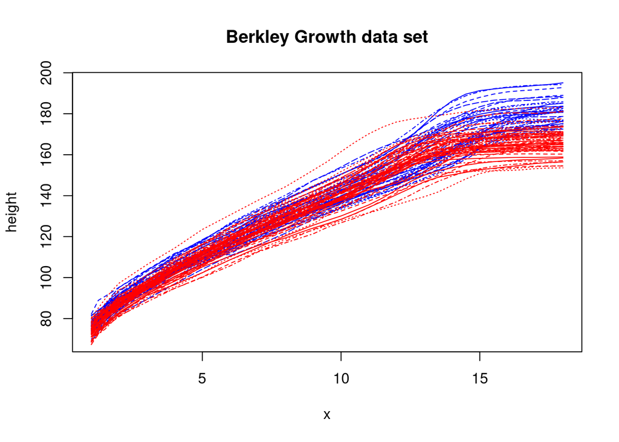

```r
matplot(data$age,data$hgtm, type='l',col='blue',ylab="height",
        main="Berkley Growth data set")
matlines(data$age,data$hgtf, type='l',col='red')
```

What if I want to test if the two curves are equal or not? Nothing simpler.. I just need to remember how permutation tests work…

## Permutation global test for equality of functional means

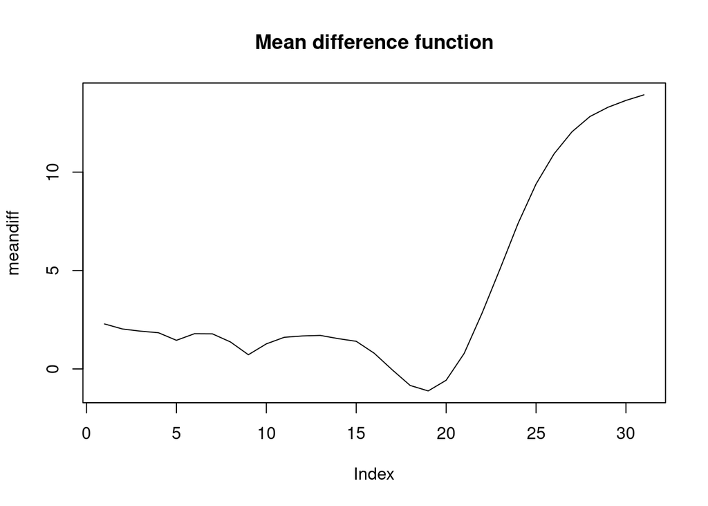

```r
seed=20
B=1e3

berkeley=rbind(t(data$hgtm),t(data$hgtf))
n=nrow(berkeley)
n_m=nrow(t(data$hgtm))
n_f=nrow(t(data$hgtf))


meandiff=(colMeans(t(data$hgtm))-colMeans(t(data$hgtf)))
plot(meandiff,type = 'l', main="Mean difference function")
```

```r
T0=sum(meandiff^2)
T0
```

```
## [1] 1208.265
```

And, Knowing that under $H_0$ the two groups of curves are i.i.d, my likelihood-invariant permutation scheme is of course label permutation, so…

```r
T0_perm=numeric(B)

for(perm in 1:B){
  permutation <- sample(n)
  berkeley_perm=berkeley[permutation,]
  perm_m = berkeley_perm[1:n_m,]
  perm_f = berkeley_perm[(n_m+1):n,]
  T0_perm[perm]=sum(((colMeans(perm_m)-colMeans(perm_f)))^2)
}

sum(T0_perm >= T0)/B
```

```
## [1] 0
```

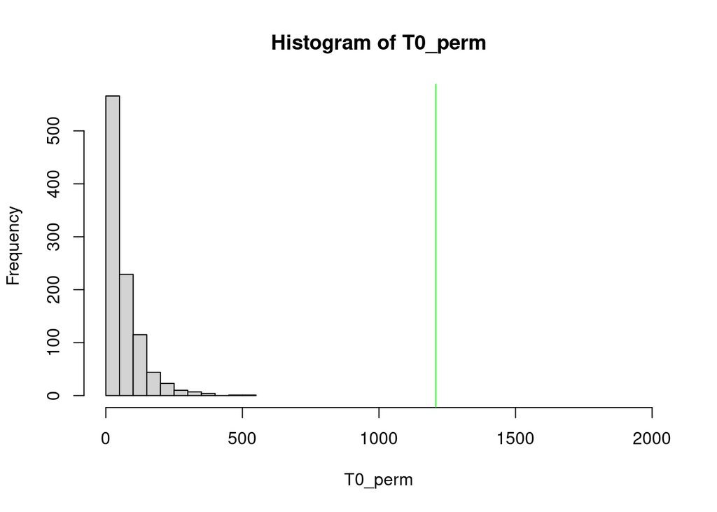

```r
hist(T0_perm,xlim = c(0,2000))
abline(v=T0,col='green')
```

What would have happened instead, if I were to test inside a group?

```r
male1=berkeley[1:(n_m/2),]
male2=berkeley[(n_m/2):n_m,]
ber_m=rbind(male1,male2)

T0=sum(((colMeans(male1)-colMeans(male2)))^2)
T0
```

```
## [1] 8.651222
```

```r
T0_perm=numeric(B)

for(perm in 1:B){
  permutation <- sample(n_m)
  berkeley_perm=ber_m[permutation,]
  perm_m = berkeley_perm[1:(n_m/2),]
  perm_f = berkeley_perm[(n_m/2):n_m,]
  T0_perm[perm]=sum(((colMeans(perm_m)-colMeans(perm_f)))^2)
}

sum(T0_perm >= T0)/B
```

```
## [1] 0.939
```

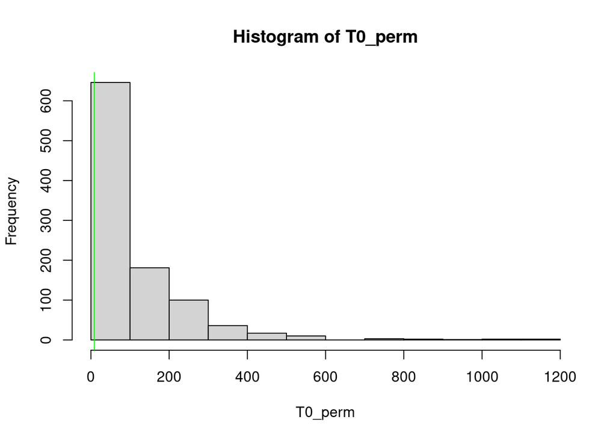

```r
hist(T0_perm)
abline(v=T0,col='green')
```

Expectedly, I am not rejecting the null hypothesis (Pvalue of the test is very high…).

## Permutation global test for equality of functional medians

Of course, I can think about using different test statistics.

To do so, though, I will need a slightly different technique to treat functional data, using the package `roahd`.

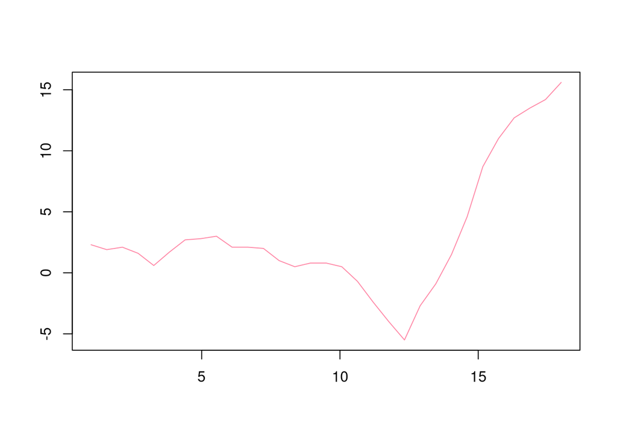

```r
hgtm_fd=fData(data$age,t(data$hgtm))
hgtf_fd=fData(data$age,t(data$hgtf))

meandiff=median_fData(hgtm_fd,type='MBD')-median_fData(hgtf_fd,type='MBD')
plot(meandiff,type = 'l')
```

```r
T0=(sum(abs(meandiff$values)))
T0
```

```
## [1] 126.5
```

And now, the test

```r
berkeley_fd=append_fData(hgtm_fd,hgtf_fd)

for(perm in 1:B){
  permutation <- sample(n)
  berkeley_perm=berkeley_fd[permutation,]
  perm_m = berkeley_perm[1:n_m,]
  perm_f = berkeley_perm[(n_m+1):n,]
  meandiff=median_fData(perm_m,type='MBD')-median_fData(perm_f,type='MBD')
  T0_perm[perm]=sum(abs(meandiff$values))
}

sum(T0_perm >= T0)/B
```

```
## [1] 0.002
```

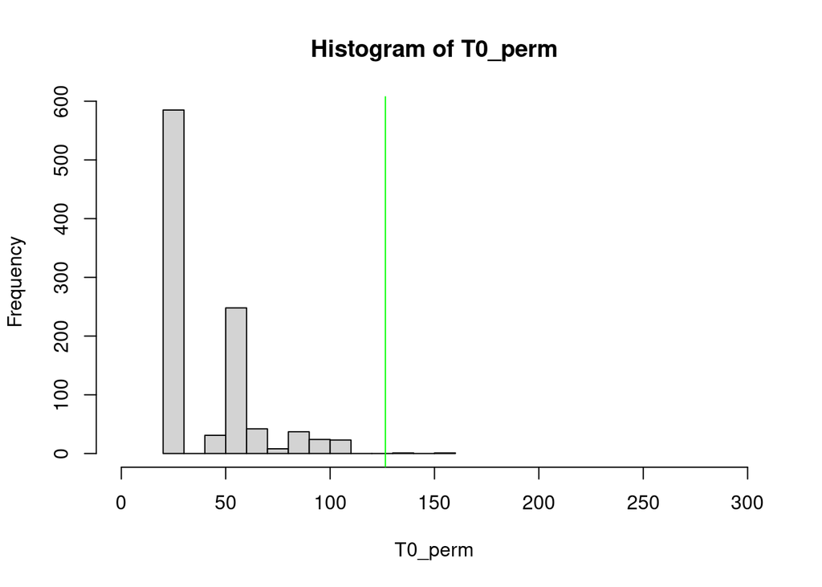

```r
hist(T0_perm,xlim = c(0,300))
abline(v=T0,col='green')
```

## Permutation global test for equality of functional populations: other statistics

- To compare two functional populations, Hotelling’s $T^2$ statistic for functional data:

```r
library(fdahotelling)

t <- test_twosample(
  x = t(data$hgtm),
  y = t(data$hgtf),
  step_size = 0.01,
  B = 100L
)
```

```
##  - P-value resolution: 0.01
##  - Computing approximate p-value using 100 random permutations.
##  - P-value will not drop below 4.07056918165599e-27 in average.
```

```r
t$statVal
```

```
## Hotelling
##  453.1464
```

#### Exercise: implement by yourselfa global test using this statistics.

## Example: last year’s January exam

Before having a fallout with his (former) friend Dr. Marius, Dr. Sulla received from him a data set of smoothed functions for the observations `CO2_emissions` along time from $1990$ to $2010$, in an equally spaced grid of $100$ elements and only for `High income` and `Low income` countries. `ex3.rds` contains a list with the data frame and the time grid.

1. By suitably defining a functional data object, plot the resulting curves for the $N = 57$ countries. Build a functional boxplot without adjusting the F value and report which countries are magnitude outliers.

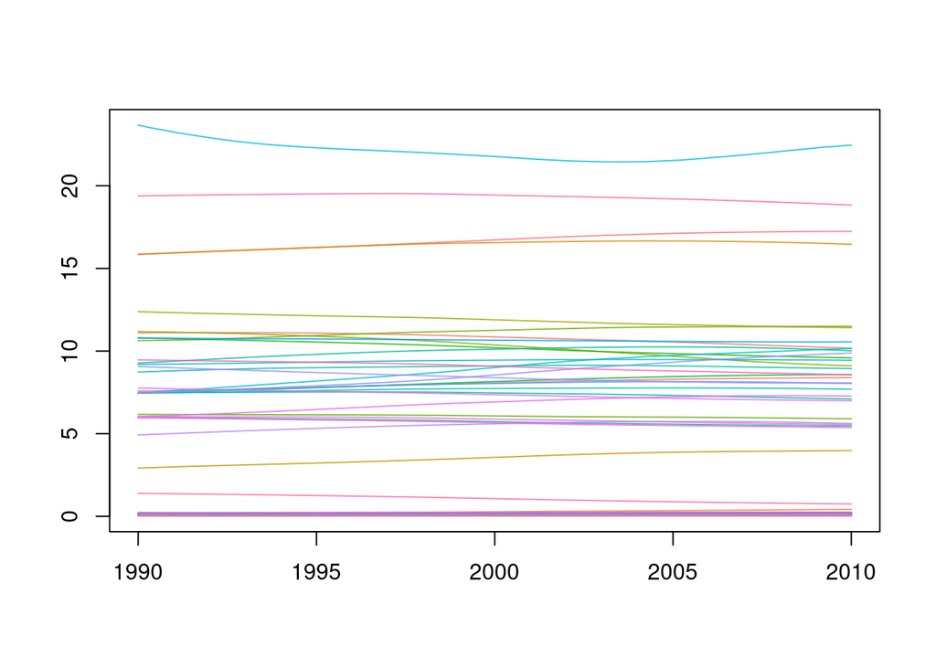

```r
library(roahd)
data3 <- readRDS(file="./data/ex3.rds")
df.func<- data3$df3
time <- data3$time
f_data <- fData(time, df.func[, -c(1,2)])
plot(f_data) # what happens if I do plot(data)?
```

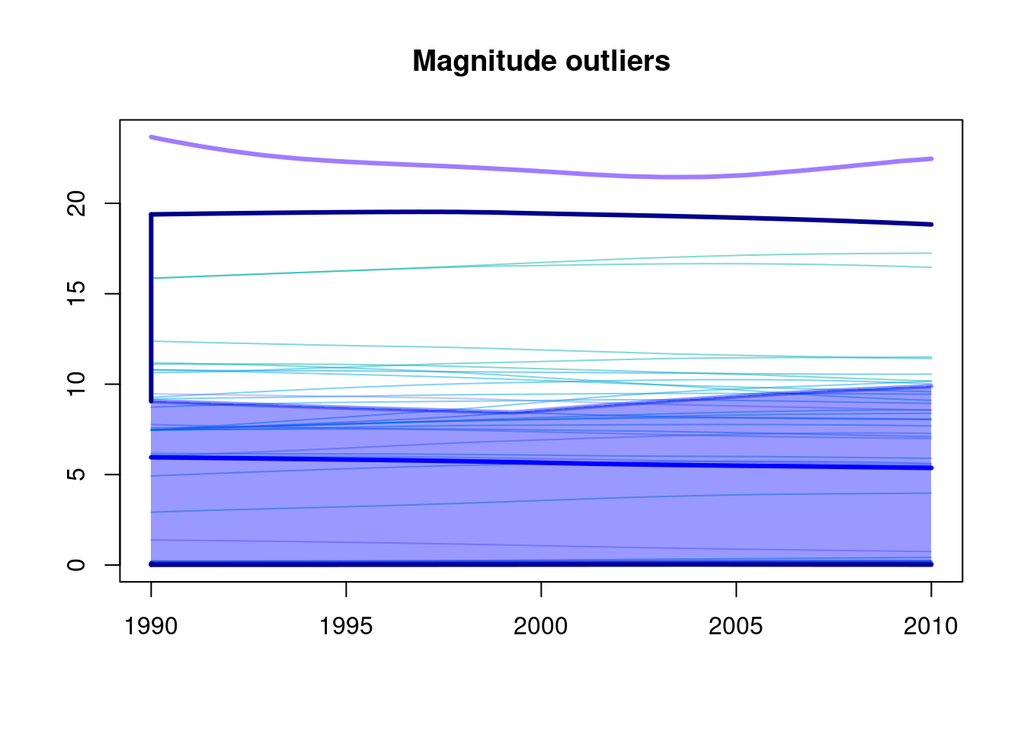

```r
fbp <- fbplot(f_data, main="Magnitude outliers",adjust = F)
```

```r
df.func[fbp$ID_outliers,c(1,2)]
```

|  | CountryCode | IncomeGroup |
| --- | --- | --- |
| 34 | LUX | High income |

```r
euclidean <- function(a, b) sqrt(sum((a - b)^2))
mean.high <- apply(df.func[df.func$IncomeGroup=="High income", -c(1,2)], MARGIN=2, FUN=mean)
mean.low <- apply(df.func[df.func$IncomeGroup=="Low income", -c(1,2)], MARGIN=2, FUN=mean)

T0 <- euclidean(mean.high, mean.low)
n <- dim(df.func)[1]
B <- 1000
Tperm <- numeric(B)
set.seed(2024)
for (b in 1:B){
  perm <- sample(1:n, replace = F)
  dfperm <- df.func
  dfperm[, -c(1,2)] <- df.func[perm, -c(1,2)]
  mean.high.perm <- apply(dfperm[dfperm$IncomeGroup=="High income", -c(1,2)], MARGIN=2, FUN=function(x){mean(x)})
  mean.low.perm <- apply(dfperm[dfperm$IncomeGroup=="Low income", -c(1,2)], MARGIN=2, FUN=function(x){mean(x)})
  Tperm[b] <- euclidean(mean.high.perm, mean.low.perm)
}
sum(Tperm>=T0)/B
```

```
## [1] 0
```

- Bonus: what if we wanted a better approximation of the $L2$ distance?

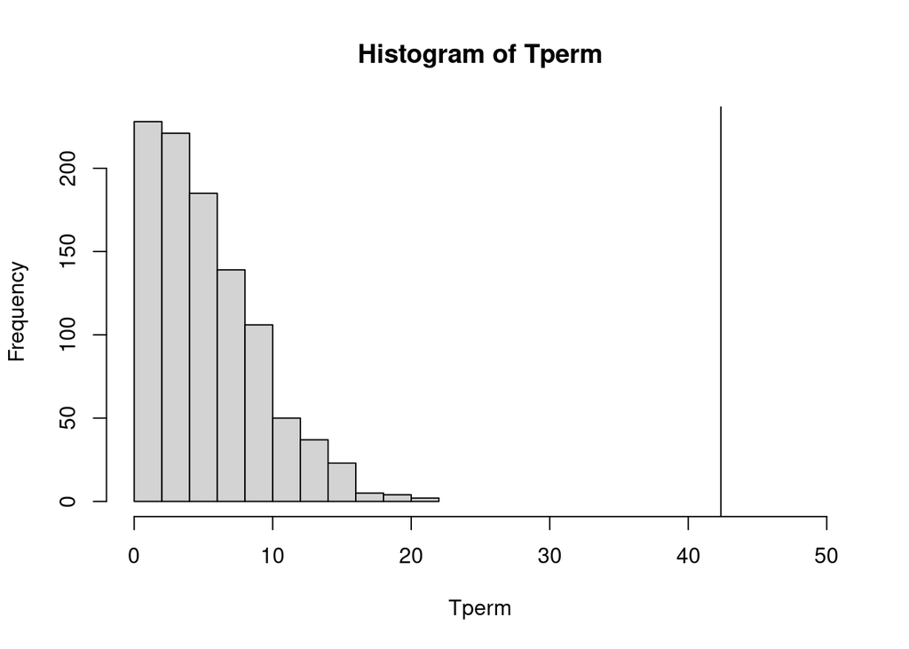

```r
L2.distance <- function(f1, f2, grid){

  return( (pracma::trapz(x=grid, y=(f1-f2)**2) )**(1/2) )
}

mean.high <- apply(df.func[df.func$IncomeGroup=="High income", -c(1,2)], MARGIN=2, FUN=mean)
mean.low <- apply(df.func[df.func$IncomeGroup=="Low income", -c(1,2)], MARGIN=2, FUN=mean)

T0 <- L2.distance(f1=mean.high, f2=mean.low, grid=time)
n <- dim(df.func)[1]
B <- 1000
Tperm <- numeric(B)
set.seed(2024)
for (b in 1:B){
  perm <- sample(1:n, replace = F)
  dfperm <- df.func
  dfperm[, -c(1,2)] <- df.func[perm, -c(1,2)]
  mean.high.perm <- apply(dfperm[dfperm$IncomeGroup=="High income", -c(1,2)], MARGIN=2, FUN=function(x){mean(x)})
  mean.low.perm <- apply(dfperm[dfperm$IncomeGroup=="Low income", -c(1,2)], MARGIN=2, FUN=function(x){mean(x)})
  Tperm[b] <-  L2.distance(f1=mean.high.perm, f2=mean.low.perm, grid=time)
}

hist(Tperm, xlim=c(0,50))
abline(v=T0)
```

```r
sum(Tperm>=T0)/B
```

```
## [1] 0
```

## Independence test

Let us do an independence test between two functional data populations.

We use the ECG data from `Lab02`.

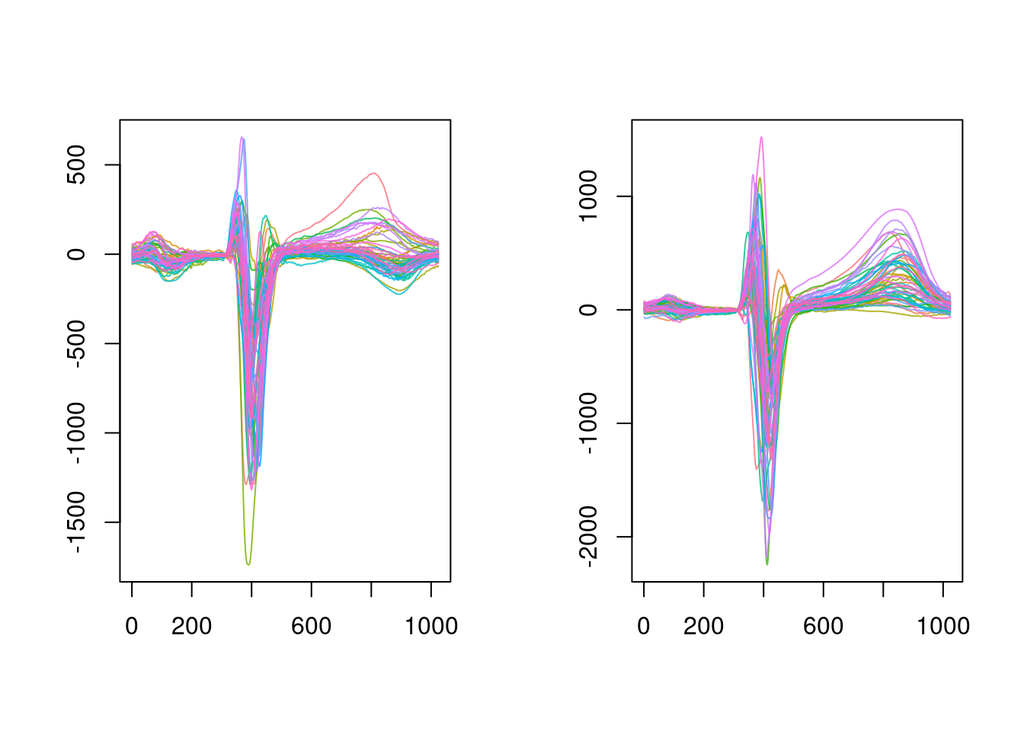

```r
bivar.func.data <- as.mfData(list(mfD_healthy$fDList[[1]], mfD_healthy$fDList[[2]]))
plot(bivar.func.data)
```

If you recall the first lectures, we can utilise Spearman’s correlation coefficient for functional data: we compute ranks with the `Modified Hypograph Index`, then a correlation coefficient, yielding a test statistic.

The permutational scheme is the same as the one we saw yesterday.

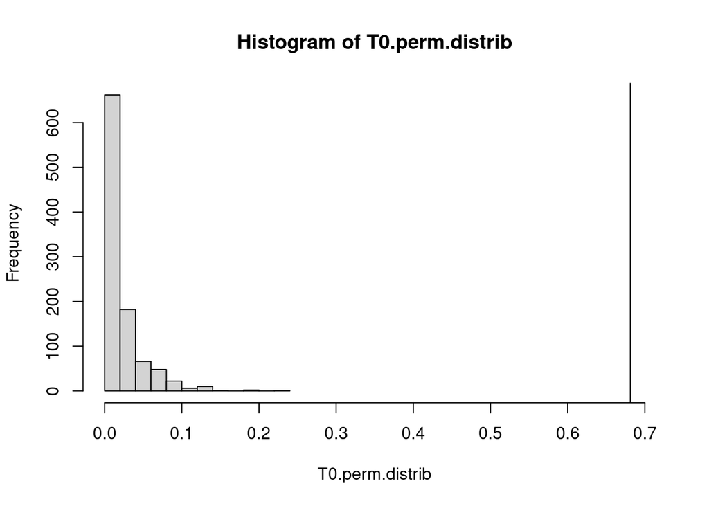

```r
MHI.first.func.dim <- MHI(bivar.func.data$fDList[[1]]) # modified hypograph index
MHI.second.func.dim <- MHI(bivar.func.data$fDList[[2]])

T0 <- cor_spearman(bivar.func.data, ordering='MHI')
T0 <- cor(MHI.first.func.dim, MHI.second.func.dim)

n <- bivar.func.data$fDList[[1]]$N
# n <- bivar.func.data$fDList[[2]]$N

T0.perm.distrib <- numeric(B)

for(perm in 1:B){
  permutation.x <- sample(n, replace=F)
  permutaiton.y <- sample(n, replace=F)
  T0.perm.distrib[perm] <- cor(MHI.first.func.dim[permutation.x],
                               as.numeric(MHI.second.func.dim)[permutaiton.y])**2
  # alternative
  #T0.perm.distrib[perm]  <- cor_spearman(as.mfData(list(mfD_healthy$fDList[[1]][permutation.x],
    #                          mfD_healthy$fDList[[2]][permutaiton.y])
      #                   ),
      #         ordering="MHI")**2


  }

hist(T0.perm.distrib, xlim=c(0,.7))
abline(v=T0)
```

```r
sum(T0.perm.distrib >=T0)/B
```

```
## [1] 0
```

#### Exercise: implement an independence test for two multivariate populations.

## An exercise: Functional Mann-Whitney

In order to explore different tests, let us exploit further depth measures.

Recall the Mann-Whitney U test: we have
$$H_0: X \stackrel{d}{=} Y \,\,\, vs. \,\,\, H_1: P[X>Y] \neq 0.5$$
and we look at possible deviations towards $H_1$ using the ranks of data.

**BUT** we have just computed ranks for Spearman’s correlation coefficient for functional data…

So all we need is a function that ranks our functional data.

```r
rank.func.data <- function(fdata){
   return (
     rank( MHI(fdata) )
           )

}
```

So we are done! We can paste Prof Vantini’s code…

We use the Berkley data set in this example.

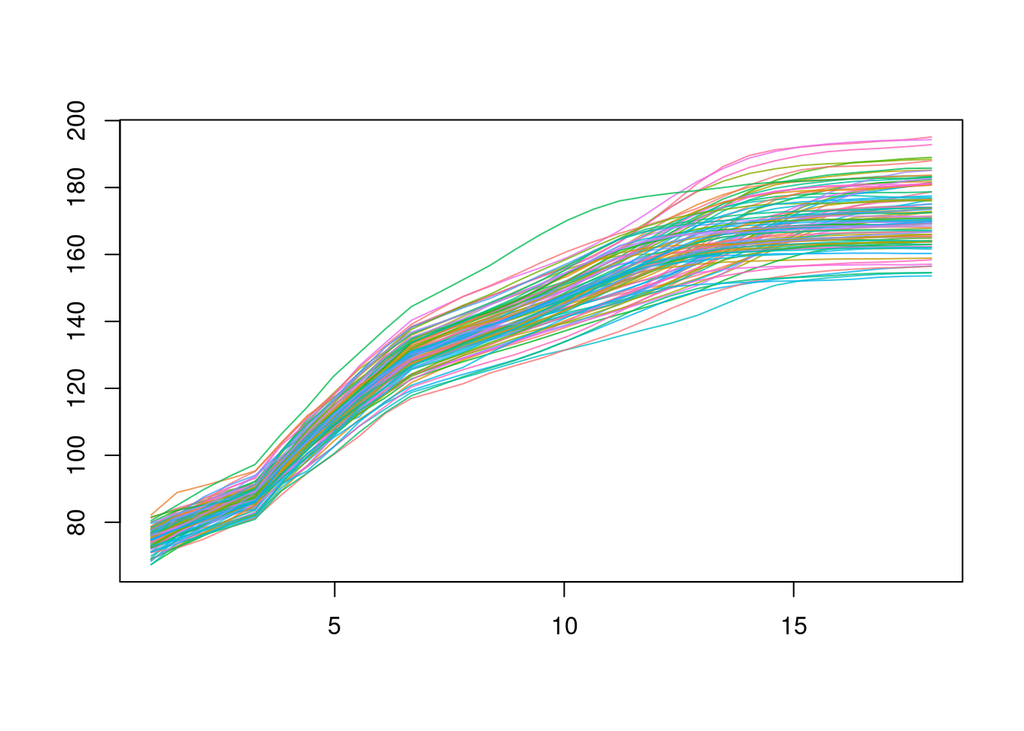

```r
func.data.bk <- fData(growth$age, t(cbind(growth$hgtm, growth$hgtf)) )
n1 <- dim(growth$hgtm)[2]
n2 <- dim(growth$hgtf)[2]
male.indices <- 1:n1
female.indices <- 1:n2 + max(male.indices)
plot(func.data.bk)
```

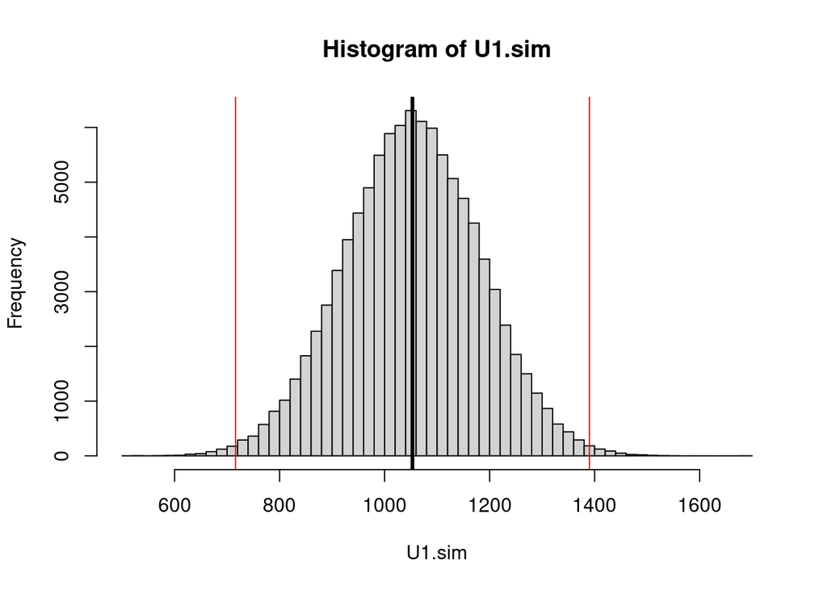

```r
R <- rank.func.data(func.data.bk)
R1 <- sum(R[male.indices])
R2 <- sum(R[female.indices])

U1 <- R1 - n1*(n1+1)/2  # Nr of wins of the 1st sample
U2 <- R2 - n2*(n2+1)/2  # Nr of wins of the 2nd sample


set.seed(24021979)
B <- 100000
U1.sim <- numeric(B)
U2.sim <- numeric(B)
n <- n1+n2
for (k in 1:B)
{
  ranks.temp <- sample(1:n)
  R1.temp <- sum(ranks.temp[1:n1])
  R2.temp <- sum(ranks.temp[(n1+1):(n1+n2)])
  U1.temp <- R1.temp - n1*(n1+1)/2
  U2.temp <- R2.temp - n2*(n2+1)/2
  U1.sim[k] <- U1.temp
  U2.sim[k] <- U2.temp
}

hist(U1.sim, breaks = 50)
abline(v = c(U1, U2), col='red')
abline(v = n1*n2/2, lwd=3)
```

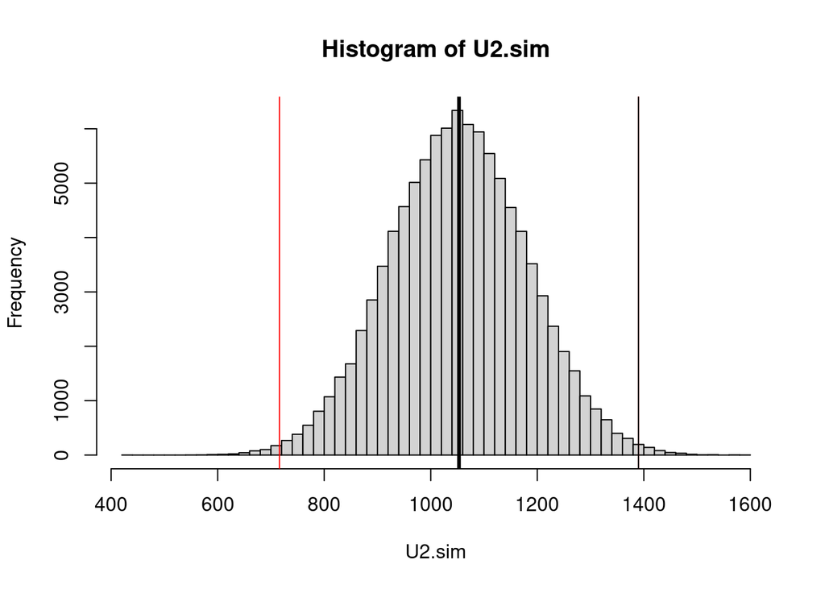

```r
hist(U2.sim, breaks = 50)
abline(v = c(U1, U2), col='red')
abline(v = n1*n2/2, lwd=3)

U.star <- max(U1, U2)
abline(v=U.star)
```

```r
p.value <- 2 * sum(U1.sim >= U.star)/B
p.value
```

```
## [1] 0.00812
```

# Local testing

Now, what I am doing here is basically is testing the hypothesis globally, I am rejecting if, for at least one time instant $t$ the two curves are statistically different. How do I tell what is that specific time instant? I use a procedure called Interval-wise Testing.

## A first look: the p-value function

2. Provide the (point-wise) mean of each group. Add them the last plot. Calculate the pointwise p-value of the permutation test using as test statistic the (absolute) difference of the means and interpret your results.

We firstly recover the plot

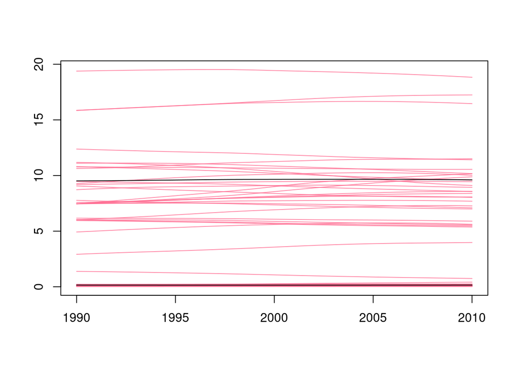

```r
plot(f_data[-fbp$ID_outliers])
mean.high <- apply(df.func[df.func$IncomeGroup=="High income", -c(1,2)], MARGIN=2, FUN=function(x){mean(x)})
lines(time, mean.high,col="black")
mean.low <- apply(df.func[df.func$IncomeGroup=="Low income", -c(1,2)], MARGIN=2, FUN=function(x){mean(x)})
lines(time, mean.low,col="black")
```

By fixing $s$, we have a typical univariate permutation test for two populations. So let us compute with the same loop all the different p-values of the different tests (one for each $s \in \mathcal{S}$)

W compute the point-wise test statistic:
$$T(s) = |\hat{\mu}_X(s) - \hat{\mu}_Y(s) |\; \forall s \in \mathcal{S}$$
where $\hat{\mu}(s)$ is the sample mean at $s$.

1. Estimate permutational distribution of the test statistic at each $s$
2. Compute p-value of every test $s \in \mathcal{S}$

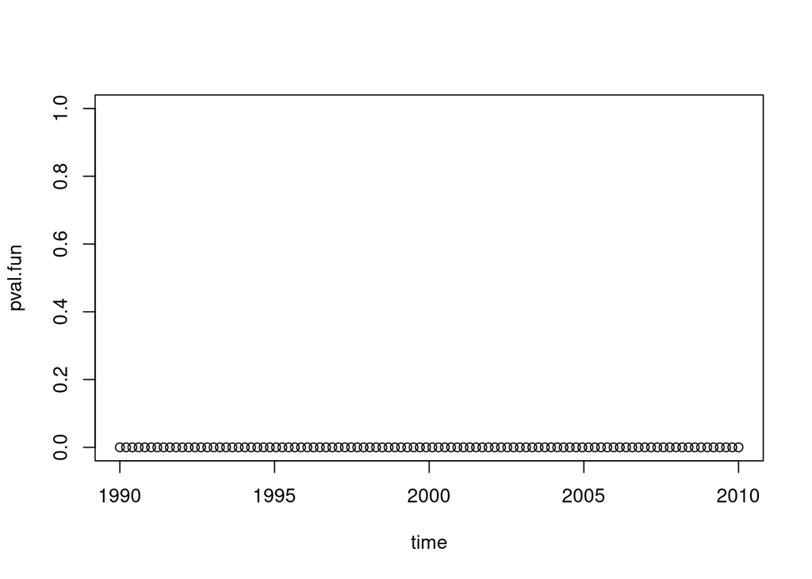

```r
uniperm=function(tindex,B=100){
  data <- df.func[, c(2,tindex+2)]
  n <- dim(data)[1]
  Tperm <- numeric(B)
  mean.high.pw <- mean(data[data$IncomeGroup=="High income", -1])
  mean.low.pw <- mean(data[data$IncomeGroup=="Low income", -1])
  t0 <- sqrt((mean.high.pw- mean.low.pw)**2)

  for(index in 1:B){
    perm <- sample(1:n, replace = F)
    dfperm <- data
    dfperm[, -1] <- data[perm, -1]
    mean.high.perm <- mean(dfperm[dfperm$IncomeGroup=="High income", -1])
    mean.low.perm <- mean(dfperm[dfperm$IncomeGroup=="Low income", -1])
  Tperm[index] <- sqrt((mean.high.perm - mean.low.perm)**2)
  }
  return(sum(Tperm>=t0)/B)
}

pval.fun=numeric(length(time))
for(index in 1:length(time)){
  set.seed(2024)
  pval.fun[index]=uniperm(index)
}

plot(time, pval.fun, ylim=c(0,1))
```

## Interval-wise tests for functional data: the adjusted p-value function

For this section of the lab, we will use the following data set:

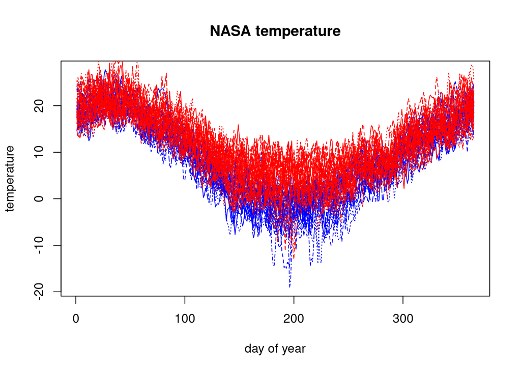

```r
library(fdatest)
data(NASAtemp)

matplot(1:365,t(NASAtemp$milan), type='l',col='blue',ylab="temperature", xlab="day of year",
        main="NASA temperature")
matlines(1:365,t(NASAtemp$paris), type='l',col='red')
```

How is Interval-Wise testing implemented?

**Details on the implementation**.

*As all FDA techniques, the procedure to evaluate the unadjusted and adjusted p-value functions and select the significant intervals of the domain described in Section 2 has to be numerically approximated to deal with the analysis of real data.* (cf. [the article](https://re.public.polimi.it/bitstream/11311/1022750/4/11311-1022750_Vantini.pdf))

- *Step 1* : **smoothing**.

- *Step 2*: pointwise p-value function:

depending on the test, whether it is two populations, location or regression, the point-wise p-value function is computed, just as before.

- *Step 3* interval-wise p-value function

The maximum of the estimated p-value function is taken over intervals for the interval-wise error rate control.

### IWT test for location

We have a functional data set, and he hypothesise if a function $m(t)$ is the true location of functional population..

Let us try with a constant function: $m(t)=4$.

```r
# Performing the ITP for two populations with the B-spline basis
ITP.result <- ITP1bspline(NASAtemp$paris,mu=4,nknots=50,B=1000)
```

[output not shown]

[output cut: 40 more lines]

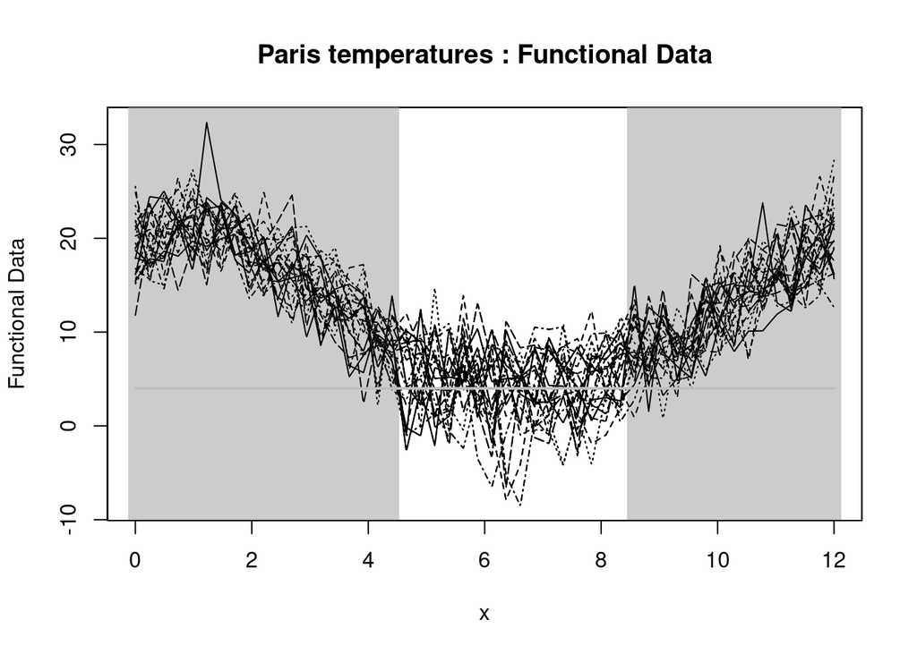

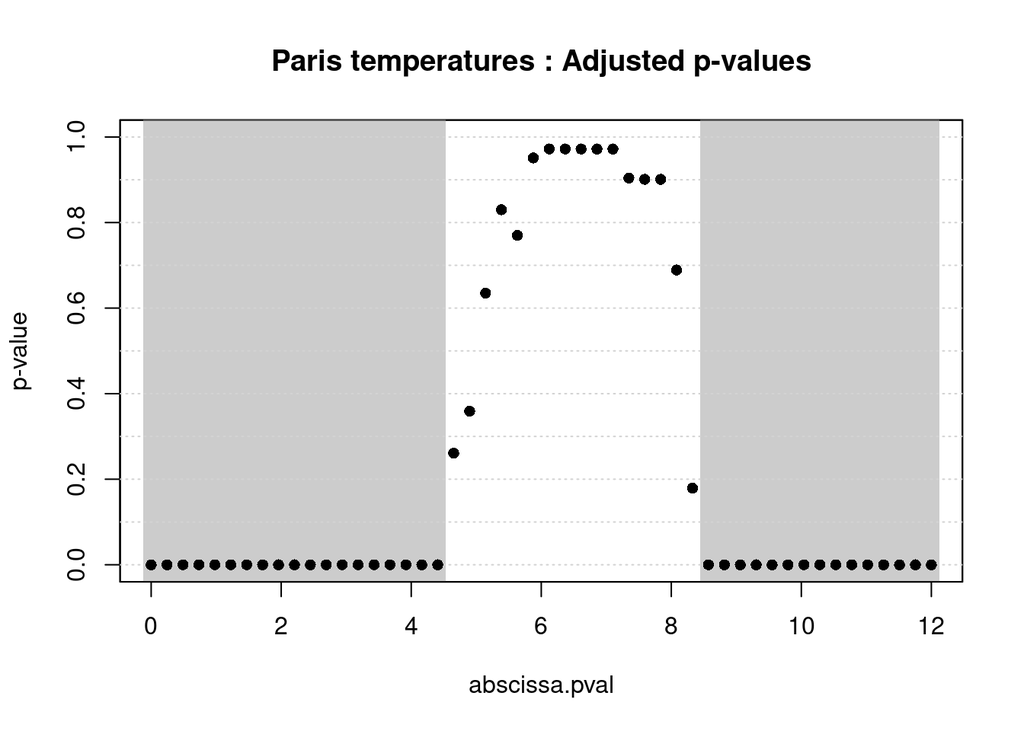

```r
# Plotting the results of the ITP
plot(ITP.result,xrange=c(0,12),main='Paris temperatures')
```

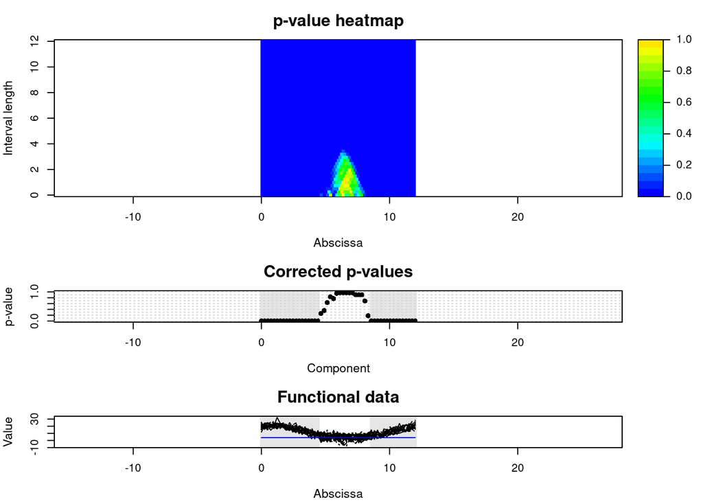

```r
# Plotting the p-value heatmap
ITPimage(ITP.result,abscissa.range=c(0,12))
```

```r
# Selecting the significant components for the radius at 5% level
which(ITP.result$corrected.pval < 0.05)
```

```
##  [1]  1  2  3  4  5  6  7  8  9 10 11 12 13 14 15 16 17 18 19 36 37 38 39 40 41
## [26] 42 43 44 45 46 47 48 49 50
```

The philosophy is similar to the one of post-hoc tests, but instead of checking components, I am checking intervals of the domain of the functional datum,

### IWT ANOVA

We can also plot the ANOV.

Remember to choose method `"responses"`: this implementes the permutations of the groups.

```r
temperature <- rbind(NASAtemp$milan,NASAtemp$paris)
groups <- c(rep(0,22),rep(1,22))
# Performing the ITP
ITP.result <- ITPaovbspline(temperature ~ groups,
                            B=1000,nknots=20,order=3,
                            method="responses")
```

[output not shown]

```r
# Summary of the ITP results
summary(ITP.result)
```

```
## $call
## ITPaovbspline(formula = temperature ~ groups, order = 3, nknots = 20,
##     B = 1000, method = "responses")
##
## $factors
##        Minimum p-value
## groups               0 ***
##
## $R2
##               Range of functional R-squared
## Min R-squared                  0.0009445336
## Max R-squared                  0.7711085208
##
## $ftest
##   Minimum p-value
## 1               0 ***
```

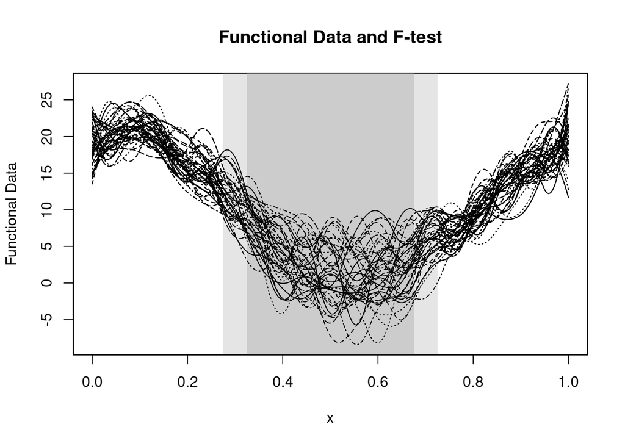

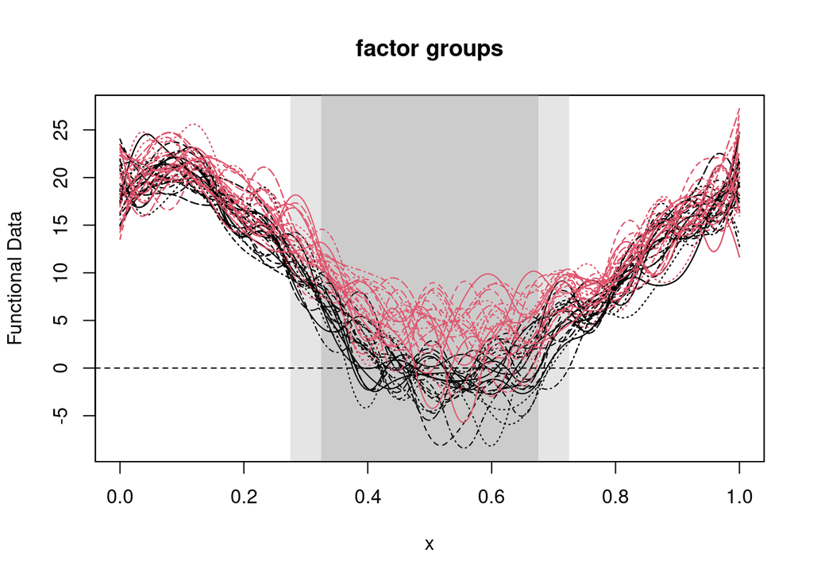

```r
# Plot of the ITP results
plot(ITP.result)
```

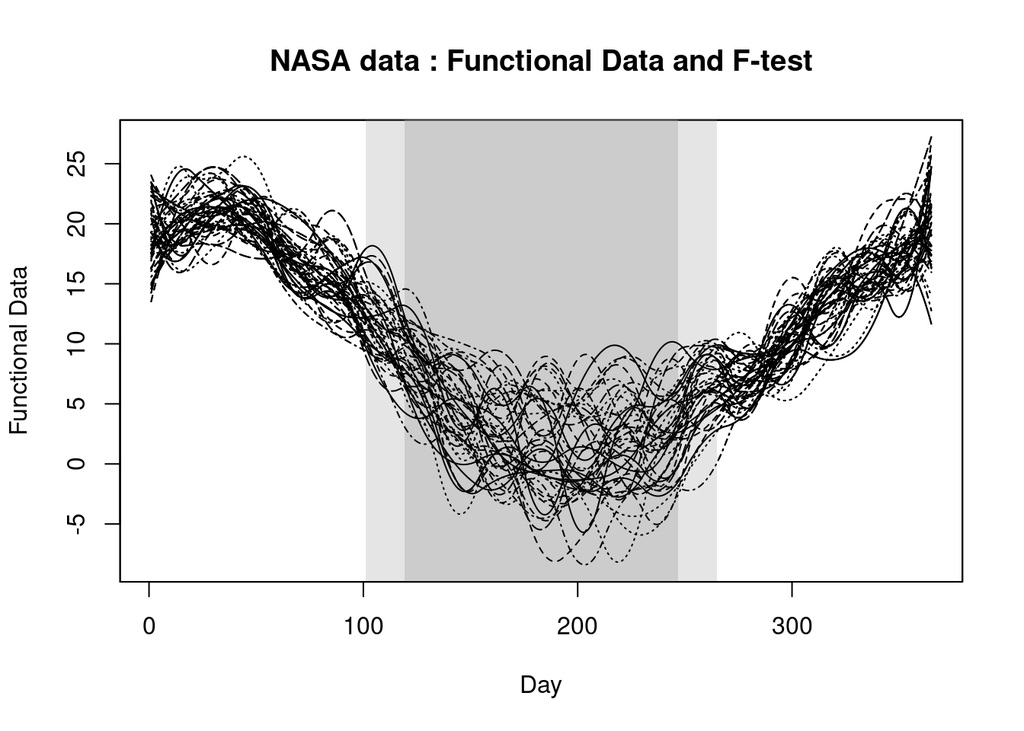

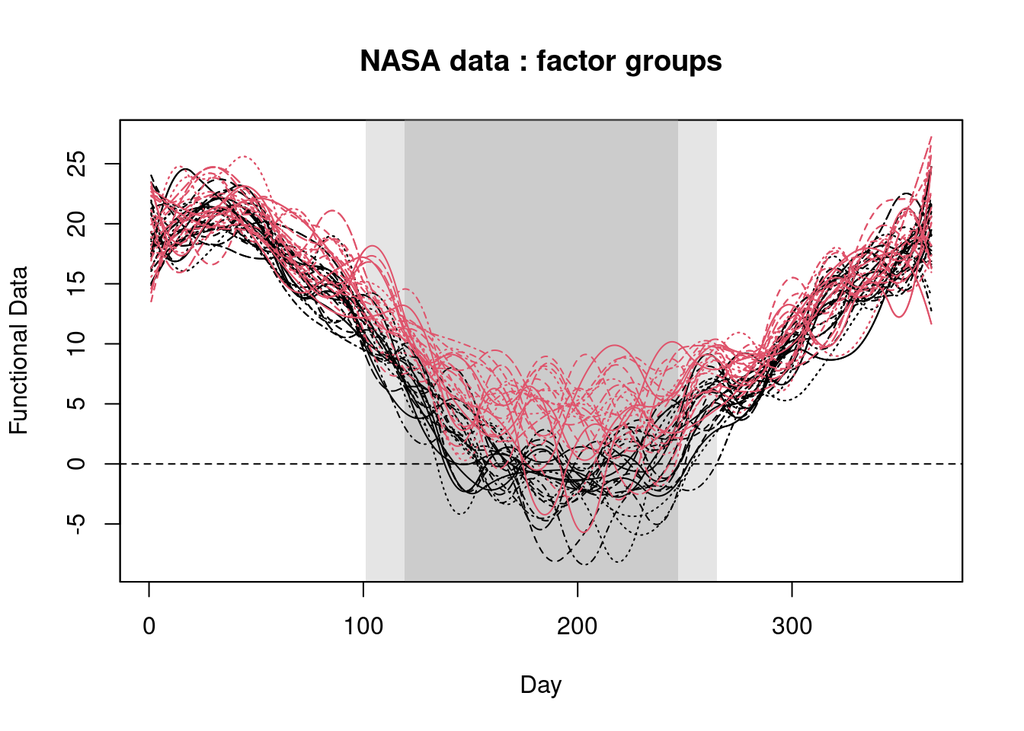

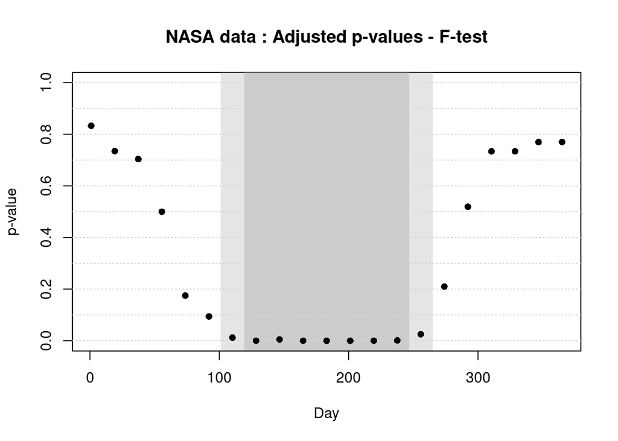

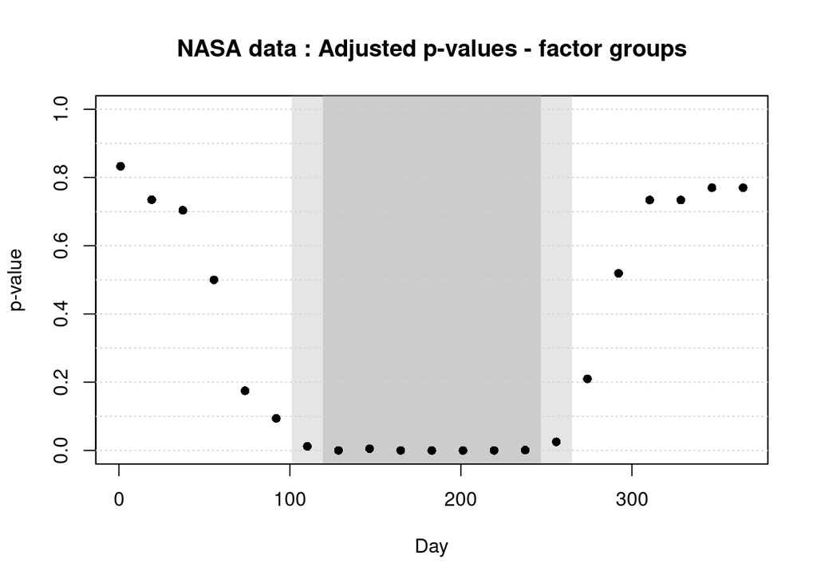

```r
# All graphics on the same device
plot(ITP.result,
     main='NASA data', plot.adjpval = TRUE,xlab='Day',xrange=c(1,365)
)
```

### IWT for functional regression

The function implements the Interval Testing Procedure for testing the significance of the effects of scalar covariates on a functional population evaluated on a uniform grid.

That is, the response is functional; and the regressor is a scalar (either continuous or categorical)

```r
# Performing the ITP
ITP.result <- ITPlmbspline(temperature ~ groups,B=1000,nknots=20)
```

[output not shown]

```r
# Summary of the ITP results
summary(ITP.result)
```

```
## $call
## ITPlmbspline(formula = temperature ~ groups, nknots = 20, B = 1000)
##
## $ttest
##             Minimum p-value
## (Intercept)               0 ***
## groups                    0 ***
##
## $R2
##               Range of functional R-squared
## Min R-squared                   0.006004052
## Max R-squared                   0.780735856
##
## $ftest
##   Minimum p-value
## 1               0 ***
```

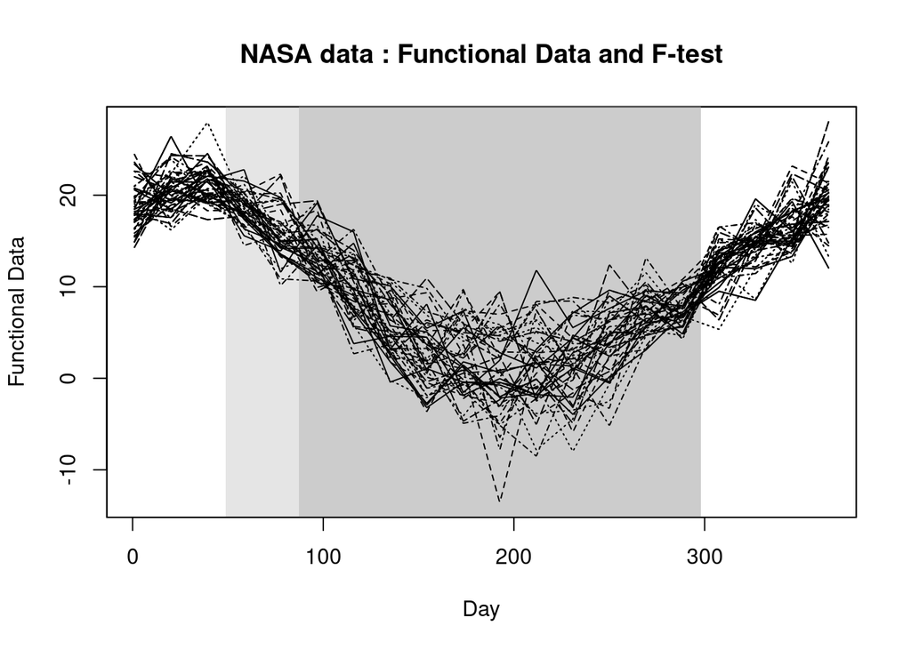

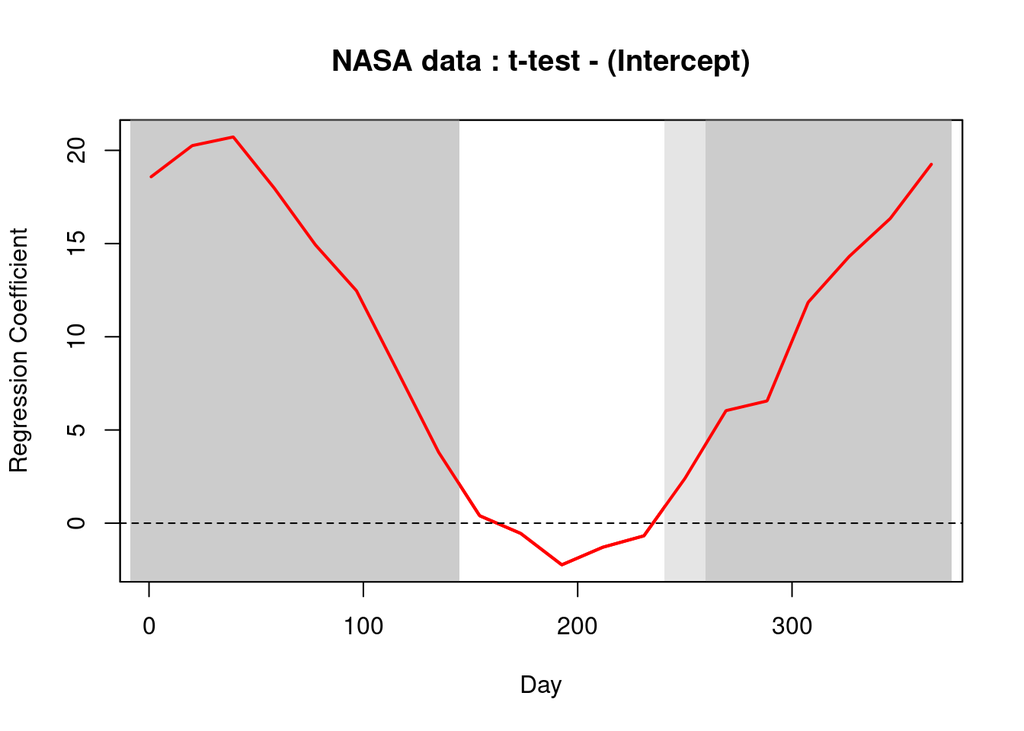

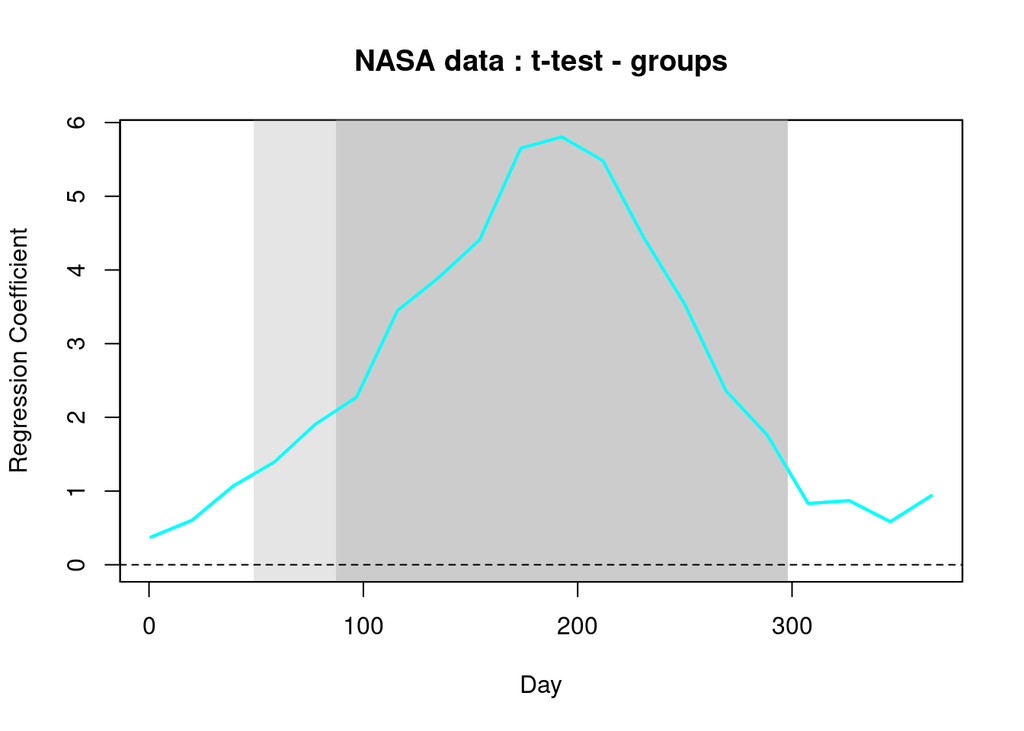

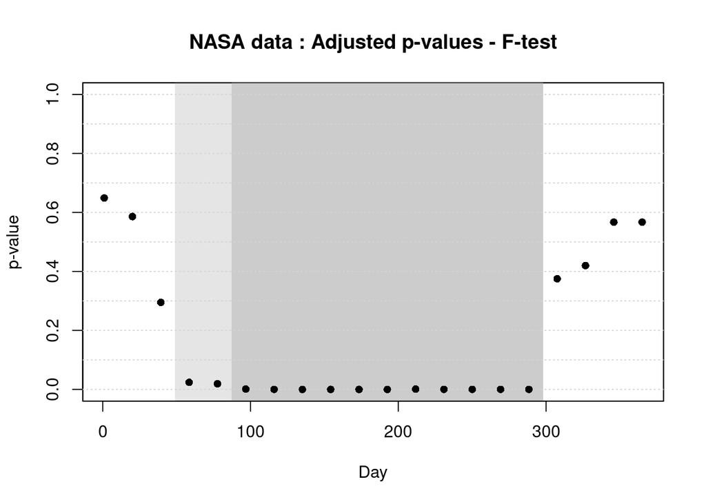

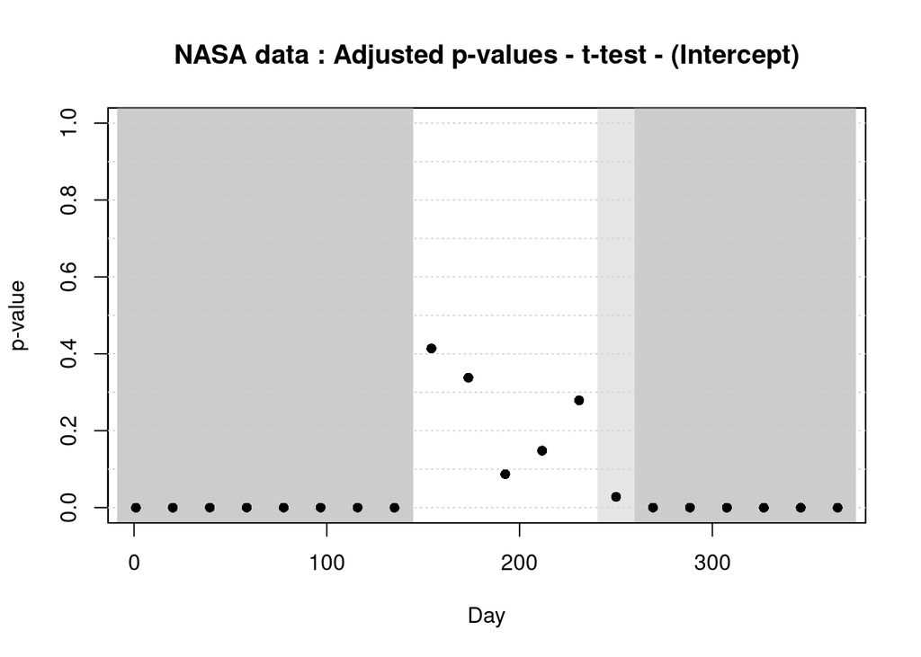

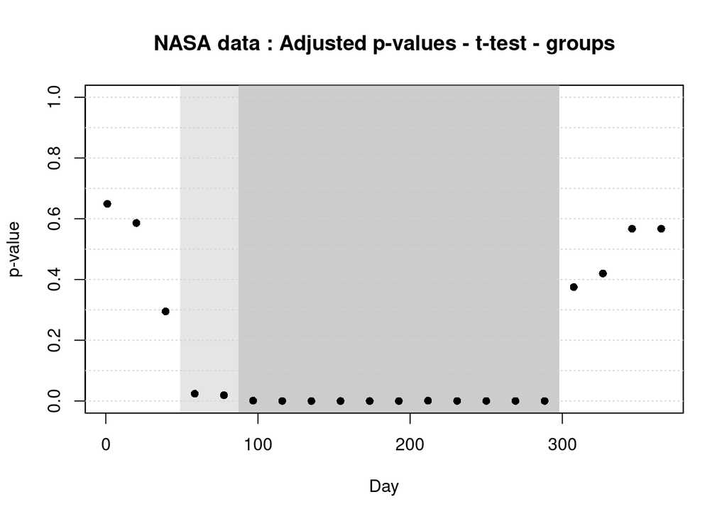

```r
# Plot of the ITP result
plot(ITP.result,main='NASA data', plot.adjpval = TRUE,xlab='Day',xrange=c(1,365))
```

### Further examples

You also saw in class an example about climate change: [this](https://arxiv.org/pdf/2306.07738) is the paper, and [here](https://github.com/NoeDebrois/NPS-Project-2023-2024) you can find an implementation students from last year did.